# Lab 7: MATH 4753

Justin Kleiber

2019-10-06

# Task 1

First, the working directory is confirmed

```r
getwd()
```

```
## [1] "C:/Users/jklei/Desktop/Projects/MATH4753/Lab7"
```

# Task 2

In order to simulate the chi-square statistic, the following `mychisim` function is made:

```r
mychisim<-function(n1=10,sigma1=3,mean1=5,iter=1000,ymax=0.1,x=20, y=0.1){    # adjust ymax to make graph fit
y1=rnorm(n1*iter,mean=mean1,sd=sigma1)# generate iter samples of size n1

data1.mat=matrix(y1,nrow=n1,ncol=iter,byrow=TRUE) # Each column is a sample size n1

ssq1=apply(data1.mat,2,var) # ssq1 is s squared

w=(n1-1)*ssq1/sigma1^2      #chi-sq stat

hist(w,freq=FALSE, ylim=c(0,ymax), # Histogram with annotation
main=substitute(paste("Sample size = ",n[1]," = ",n1," statistic = ",chi^2)),
xlab=expression(paste(chi^2, "Statistic",sep=" ")), las=1)
lines(density(w),col="Blue",lwd=3) # add a density plot
curve(dchisq(x,n1-1),add=TRUE,col="Red",lty=2,lwd=3) # add a theoretical curve
title=expression(chi^2==frac((n[1]-1)*s^2,sigma^2)) #mathematical annotation -see ?plotmath
legend(x,y,c("Simulated","Theoretical"),col=c("Blue","Red"),lwd=4,lty=1:2,bty="n",title=title) # Legend #
return(list(w=w,summary=summary(w),sd=sd(w),fun="Chi-sq")) # some output to use if needed
}
```

The chi-square statistic is used to generate the following four plots.

- Plot 1

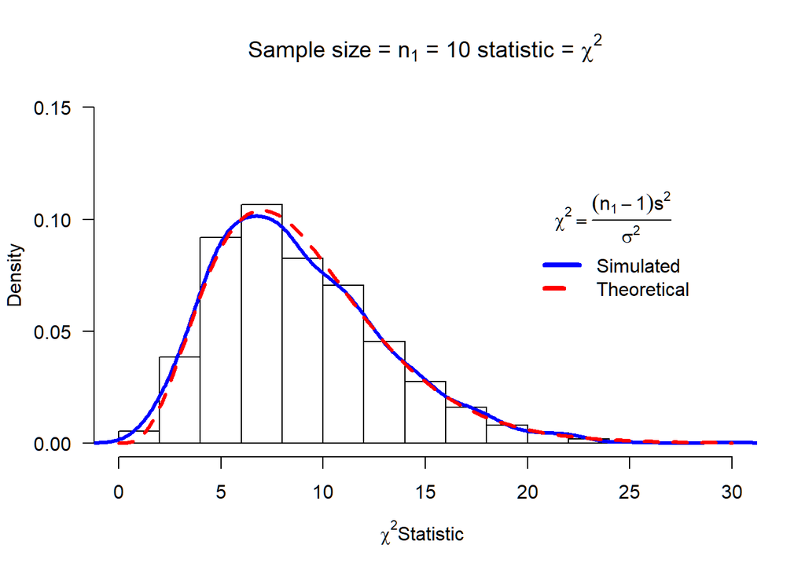

```r
plot1 = mychisim(n1 = 10, iter = 1000, mean1 = 10, sigma1 = 4, ymax = 0.15)
```

- Plot 2

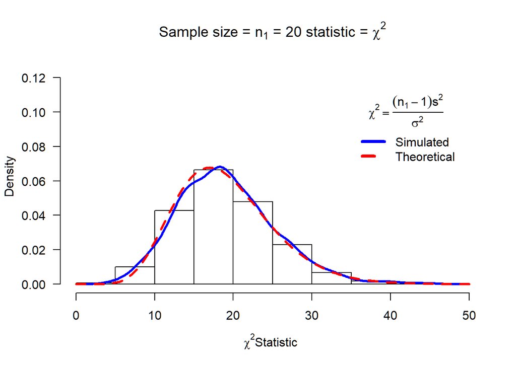

```r
plot2 = mychisim(n1 = 20, iter = 1000, mean1 = 10, sigma1 = 4, ymax = 0.125, x = 35)
```

- Plot 3

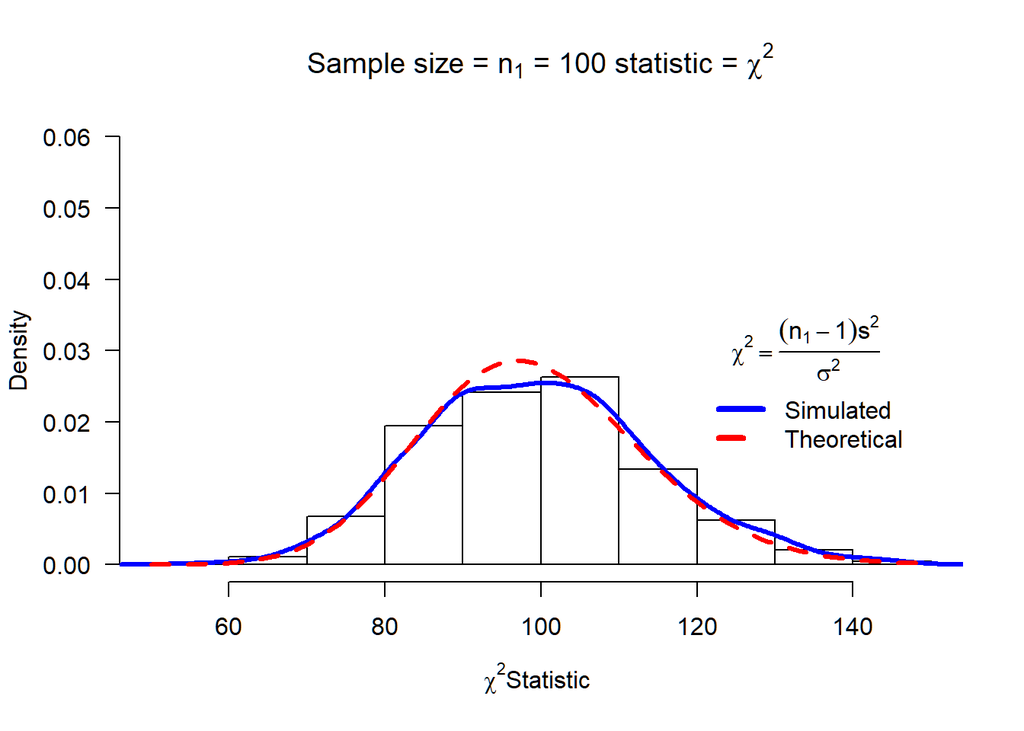

```r
plot3 = mychisim(n1 = 100, iter = 1000, mean1 = 10, sigma1 = 4, ymax = 0.06, x=120, y = 0.03)
```

- Plot 4

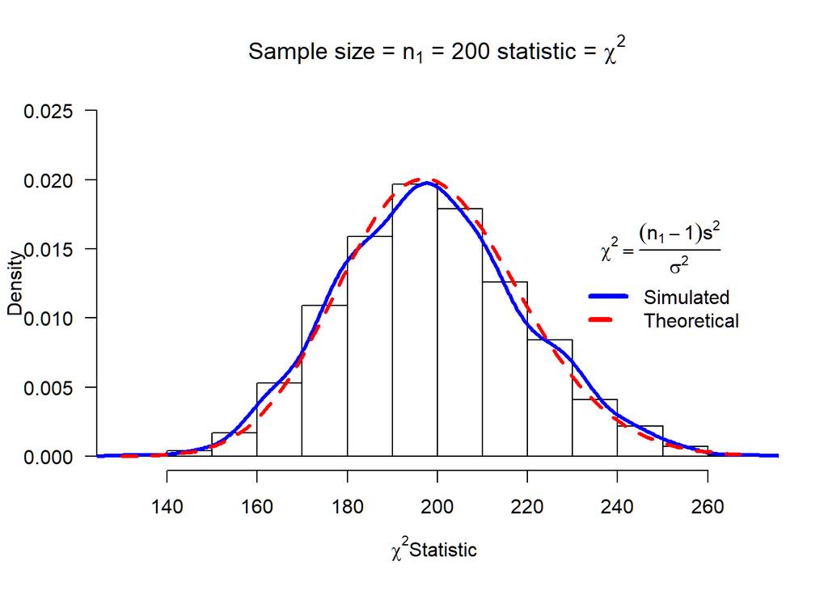

```r
plot4 = mychisim(n1 = 200, iter = 1000, mean1 = 10, sigma1 = 4, ymax = 0.025, x = 230, y = 0.015)
```

The function also does other things besides plot data. Below, the function is invoked, and the w vector is represented with a histogram.

```r
chisq = mychisim(n1 = 10, iter = 1500, mean1=20, sigma1 = 10, y = 0.06)
```

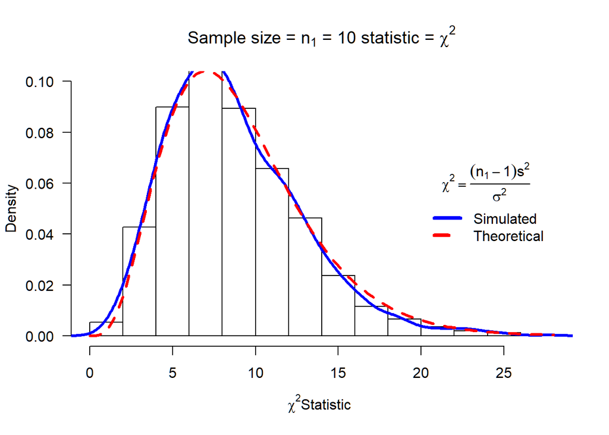

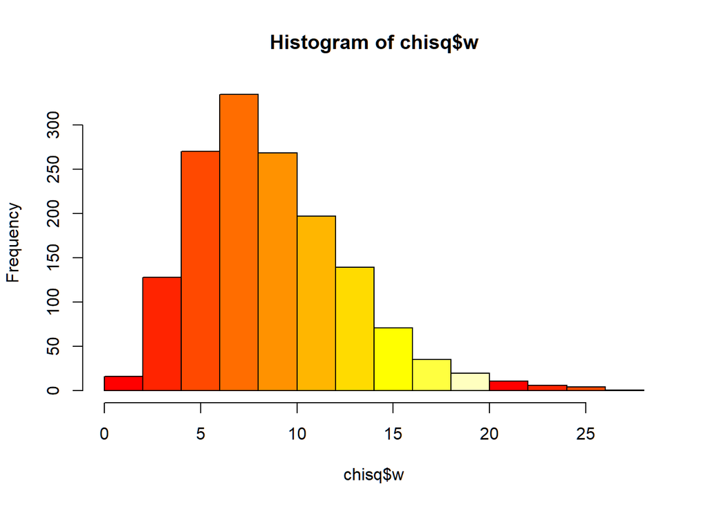

```r
hist(chisq$w, col=heat.colors(10))
```

# Task 3

In a similar simulation as task 2, the T statistic is simulated by the following function named `myTsim`:

```r
myTsim<-function(n1=10,sigma1=3,mean1=5,iter=1000,ymax=0.1,x=1.5,y=0.3,...){    # adjust ymax to make graph fit
y1=rnorm(n1*iter,mean=mean1,sd=sigma1)# generate iter samples of size n1

data1.mat=matrix(y1,nrow=n1,ncol=iter,byrow=TRUE) # Each column is a sample size n1

sd1=apply(data1.mat,2,sd) # sd
ybar=apply(data1.mat,2,mean)  # mean

w=(ybar-mean1)/(sd1/sqrt(n1))      #T stat

hist(w,freq=FALSE, ylim=c(0,ymax), # Histogram with annotation
main=substitute(paste("Sample size = ",n[1]," = ",n1," statistic = ",T," iterations= ",iter)),
xlab=expression(paste(T, "Statistic",sep=" ")), las=1)
lines(density(w),col="Blue",lwd=3) # add a density plot
curve(dt(x,n1-1),add=TRUE,col="Red",lty=2,lwd=3) # add a theoretical curve
title=expression(T==frac((bar(y)-mu),s/sqrt(n1))) #mathematical annotation -see ?plotmath
legend(x,y,c("Simulated","Theoretical"),col=c("Blue","Red"),lwd=4,lty=1:2,bty="n",title=title) # Legend #
return(list(w=w,summary=summary(w),sd=sd(w),fun="T")) # some output to use if needed
}
```

- Plot 1:

```r
p1 = myTsim(n1 = 10, iter = 1000, mean1 = 10, sigma1 = 4, ymax = 0.45)
```

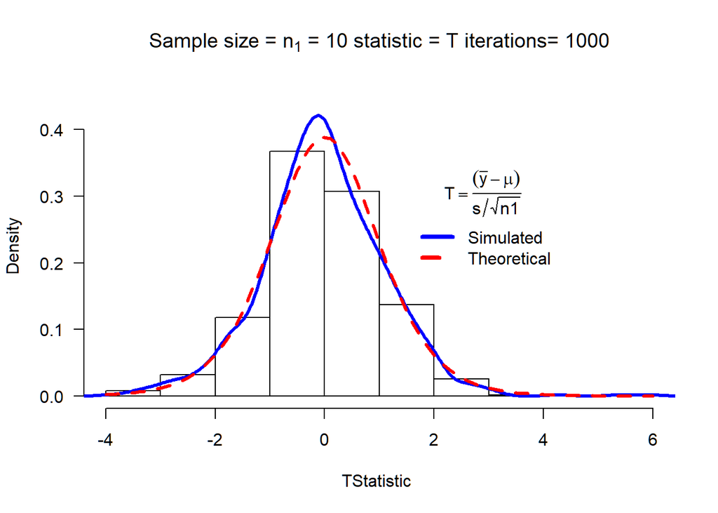

- Plot 2:

```r
p2 = myTsim(n1 = 20, iter = 1000, mean1 = 10, sigma1 = 4, ymax = 0.45)
```

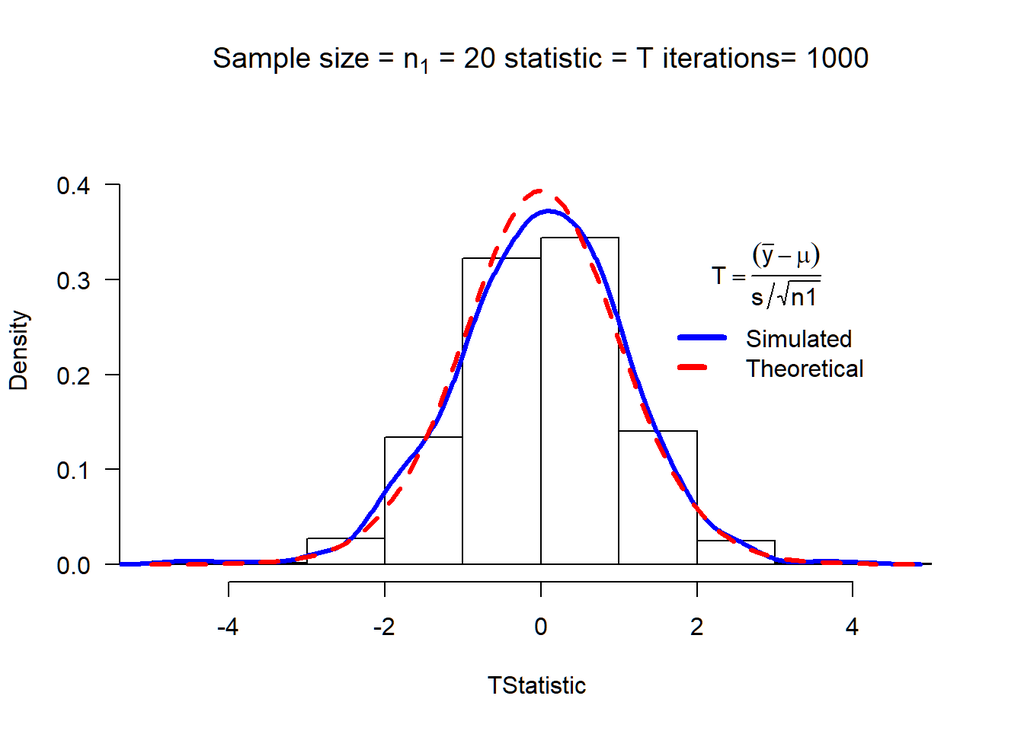

- Plot 3:

```r
p3 = myTsim(n1 = 100, iter = 1000, mean1 = 10, sigma1 = 4, ymax = 0.45)
```

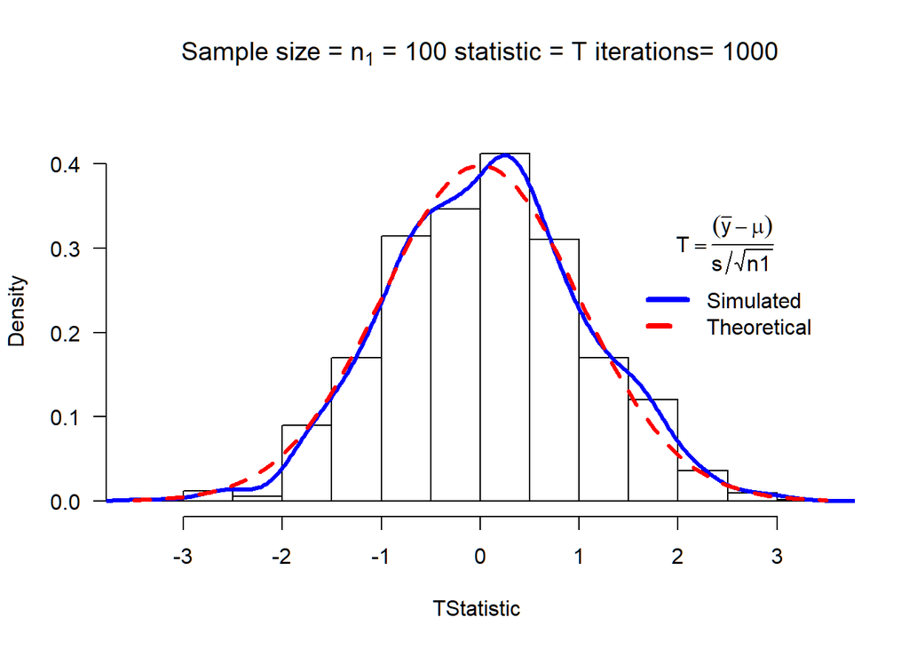

- Plot 4:

```r
p4 = myTsim(n1 = 200, iter = 1000, mean1 = 10, sigma1 = 4, ymax = 0.45)
```

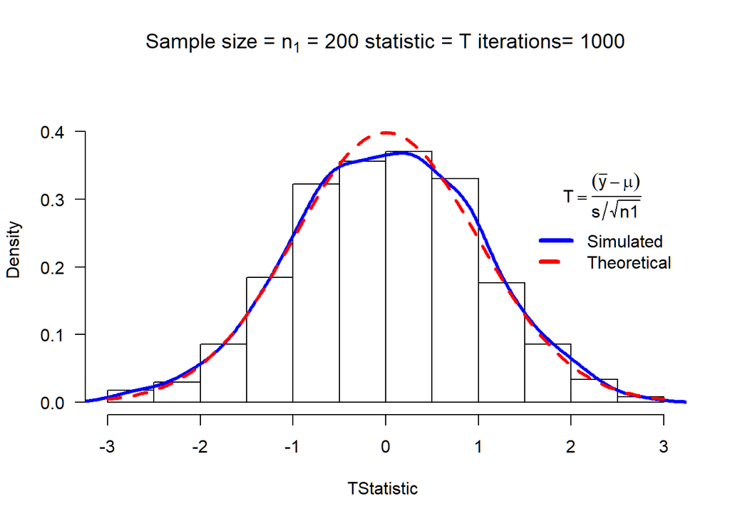

For the same setup as above with the histogram, the `myTsim` function can also provide a histogram through returning the T value at each iteration.

```r
T = myTsim(n1 = 10, iter = 1500, mean1 = 20, sigma1 = 10, ymax = 0.45)
```

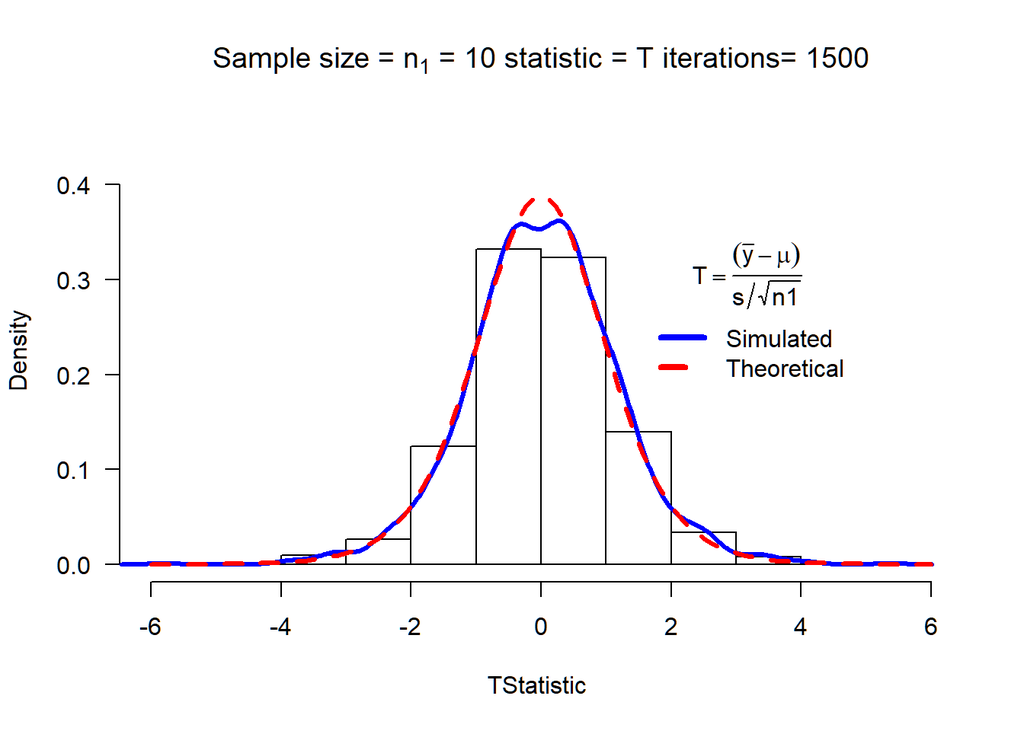

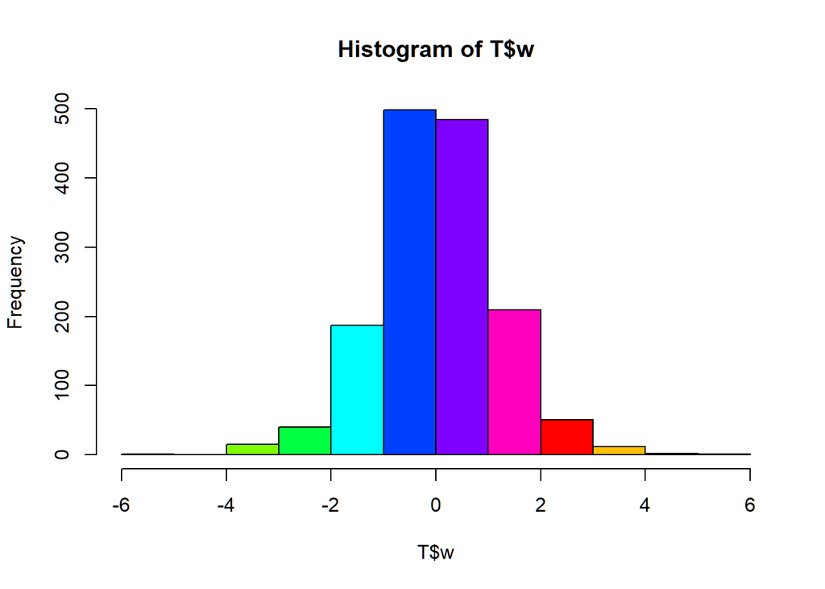

```r
hist(T$w, col = rainbow(8))
```

# Task 4

Just as one population’s sampling can be simulated, so can two populations at the same time. To do this, the `mychisim2` function is used.

```r
mychisim2<-function(n1=10,n2=14,sigma1=3,sigma2=3,mean1=5,mean2=10,iter=1000,ymax=0.07,x=40,y=0.04,...){    # adjust ymax to make graph fit
y1=rnorm(n1*iter,mean=mean1,sd=sigma1)# generate iter samples of size n1
y2=rnorm(n2*iter,mean=mean2,sd=sigma2)
data1.mat=matrix(y1,nrow=n1,ncol=iter,byrow=TRUE) # Each column is a sample size n1
data2.mat=matrix(y2,nrow=n2,ncol=iter,byrow=TRUE)
ssq1=apply(data1.mat,2,var) # ssq1 is s squared
ssq2=apply(data2.mat,2,var)
spsq=((n1-1)*ssq1 + (n2-1)*ssq2)/(n1+n2-2) # pooled s squared
w=(n1+n2-2)*spsq/(sigma1^2)#sigma1=sigma2,  Chi square stat
hist(w,freq=FALSE, ylim=c(0,ymax), # Histogram with annotation
main=substitute(paste("Sample size = ",n[1]+n[2]," = ",n1+n2," statistic = ",chi^2)),
xlab=expression(paste(chi^2, "Statistic",sep=" ")), las=1)
lines(density(w),col="Blue",lwd=3) # add a density plot
curve(dchisq(x,n1+n2-2),add=TRUE,col="Red",lty=2,lwd=3) # add a theoretical curve
title=expression(chi^2==frac((n[1]+n[2]-2)*S[p]^2,sigma^2)) #mathematical annotation -see ?plotmath
legend(x,y,c("Simulated","Theoretical"),col=c("Blue","Red"),lwd=4,lty=1:2,bty="n",title=title) # Legend #
return(list(w=w,summary=summary(w),sd=sd(w),fun="Chi-sq")) # some output to use if needed
}
```

Four simulations are run on two normal populations at a time and plots are generated below:

- Plot 1

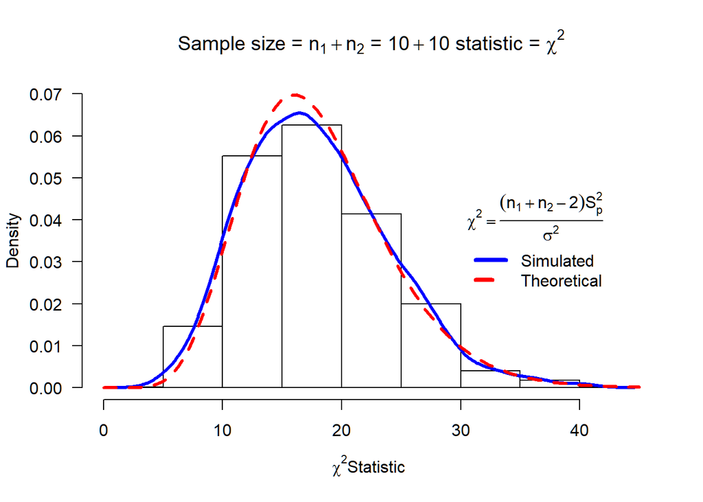

```r
c2_plot1 = mychisim2(n1 = 10, n2 = 10, mean1 = 5, mean2 = 10, sigma1 = 4, sigma2 = 4, iter = 1000, x = 30)
```

- Plot 2

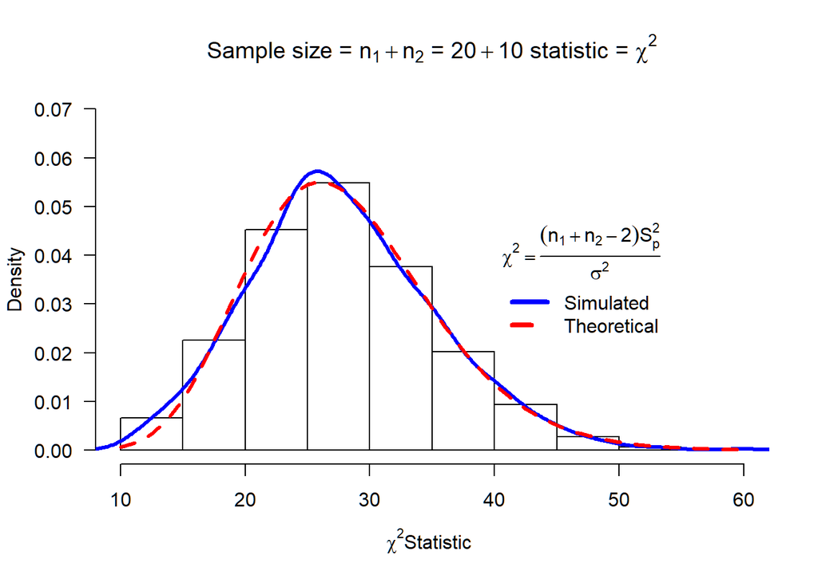

```r
c2_plot2 = mychisim2(n1 = 20, n2 = 10, mean1 = 3, mean2 = 5, sigma1 = 10, sigma2 = 10, iter = 1000)
```

- Plot 3

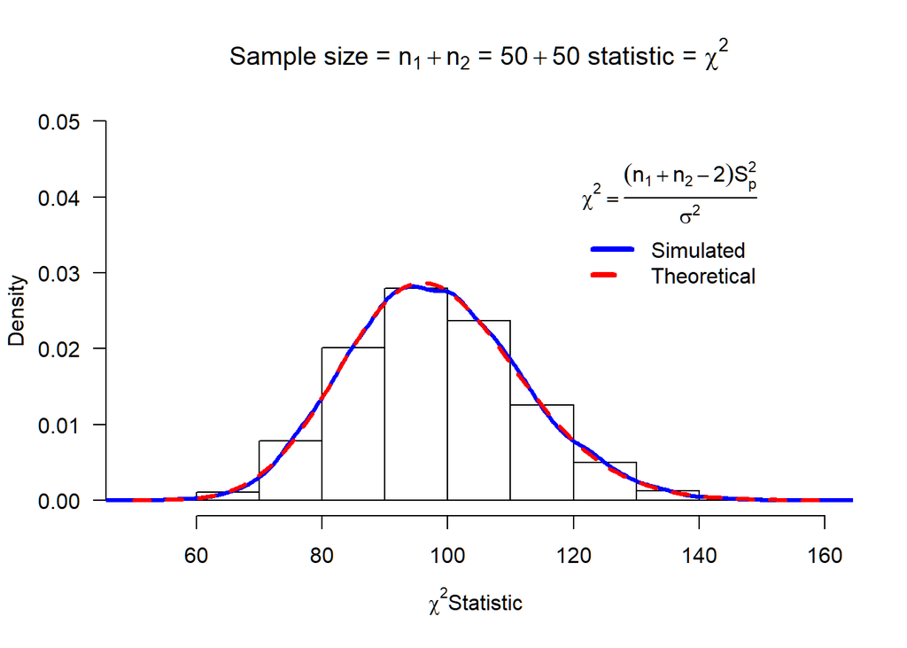

```r
c2_plot3 = mychisim2(n1 = 50, n2 = 50, mean1 = 5, mean2 = 10, sigma1 = 4, sigma2 = 4, iter = 10000, x = 120, ymax = 0.05)
```

- Plot 4

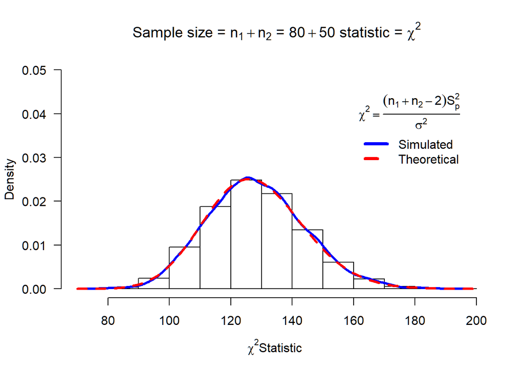

```r
c2_plot4 = mychisim2(n1 = 80, n2 = 50, mean1 = 3, mean2 = 5, sigma1 = 10, sigma2 = 10, iter = 10000, x = 160, ymax = 0.05)
```

Using the default values of `mychisim2` and setting `iter = 10000` yields the following histogram:

```r
c2 = mychisim2(iter=10000)
```

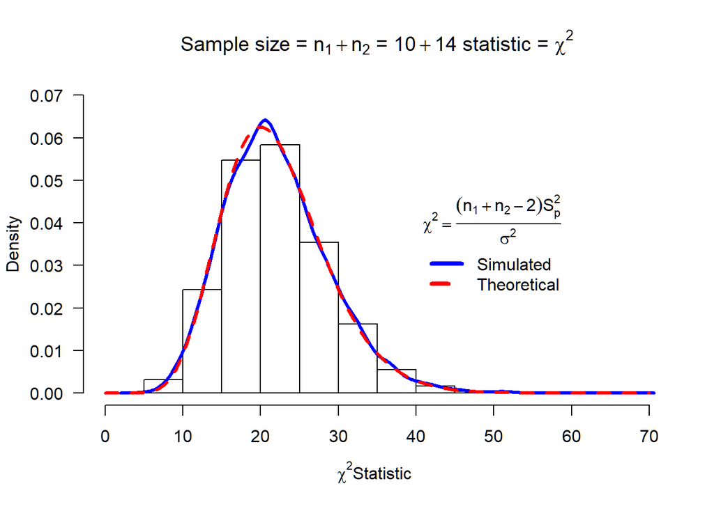

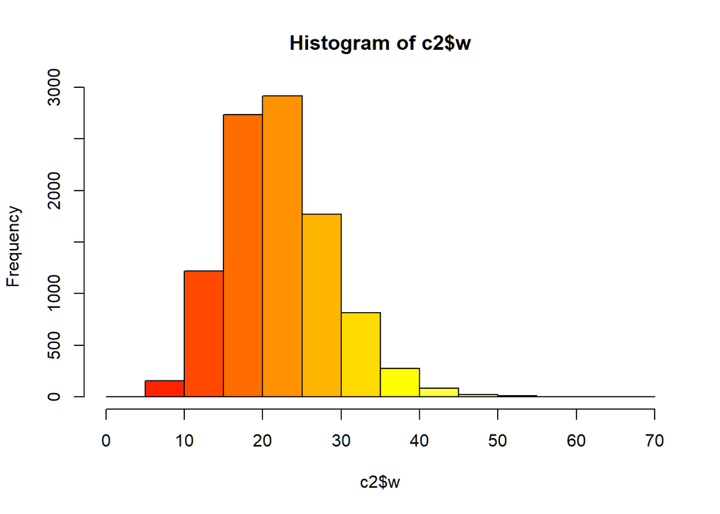

```r
hist(c2$w, col = heat.colors(10))
```

# Task 5

In order to make a T statistic from two distributions, similar logic from Task 4 can be applied to the `myTsim` function in Task 3. To make the legend placement easier, the following `myTsim2` function can be used in an R script to allow the user to click to select where the legend is placed:

```r
myTsim2<-function(n1=10,n2=14,sigma1=3,sigma2=3,mean1=5,mean2=10,iter=1000,ymax=0.5,...){
y1=rnorm(n1*iter,mean=mean1,sd=sigma1)# generate iter samples of size n1
y2=rnorm(n2*iter,mean=mean2,sd=sigma2)
data1.mat=matrix(y1,nrow=n1,ncol=iter,byrow=TRUE) # Each column is a sample size n1
data2.mat=matrix(y2,nrow=n2,ncol=iter,byrow=TRUE)
ssq1=apply(data1.mat,2,var) # ssq1 is s squared
ybar1= apply(data1.mat,2,mean)
ssq2=apply(data2.mat,2,var)
ybar2=apply(data2.mat,2,mean)
spsq=((n1-1)*ssq1 + (n2-1)*ssq2)/(n1+n2-2) # pooled s squared
w=((ybar1-ybar2)-(mean1-mean2))/sqrt(spsq*(1/n1+1/n2))#sigma1=sigma2,  Chi square stat
hist(w,freq=FALSE, ylim=c(0,ymax), # Histogram with annotation
main=substitute(paste("Sample size = ",n[1]+n[2]," = ",n1+n2," statistic = ",T)),
xlab=paste(" T Statistic",sep=""), las=1)
lines(density(w),col="Blue",lwd=3) # add a density plot
curve(dt(x,n1+n2-2),add=TRUE,col="Red",lty=2,lwd=3) # add a theoretical curve
title=expression(T==frac((bar(Y)[1]-bar(Y)[2])-(mu[1]-mu[2]),S[p]*sqrt(frac(1,n[1])+frac(1,n[2])))) #mathematical annotation -see ?plotmath
legend(locator(1),c("Simulated","Theoretical"),col=c("Blue","Red"),lwd=4,lty=1:2,bty="n",title=title)# Legend #
return(list(w=w,summary=summary(w),sdw=sd(w),fun="T")) # some output to use if needed
}
```

This function calculates the T statistic as follows:
$$T = \frac{(\bar{Y_1} - \bar{Y_2}) - (\mu_1 - \mu_2)}{S_p\sqrt{\frac{1}{n_1} + \frac{1}{n_2}}}\\
S_p^2 = \frac{(n_1 - 1)S_1^2 + (n_2 - 1)S_2^2}{n_1 + n_2 - 2}$$

The way this works is two normal distributions are sampled, $Y_1$ and $Y_2$. The means of these distributions is found, and the $\mu_1$ and $\mu_2$ variables are given as parameters. $S_p$ is calculated by taking the two sample sizes and the sample variances (from $Y_1$ and $Y_2$) and putting them into the second equation above. From this the T statistic can be calculated for two distributions.

In order to simulate the T statistic from 2 distributions, the following R code was written. As seen below, the program makes two normal distributions as samples, gets their means and variances, and then runs the two functions presented above.

```r
y1=rnorm(n1*iter,mean=mean1,sd=sigma1)# generate iter samples of size n1
y2=rnorm(n2*iter,mean=mean2,sd=sigma2)
data1.mat=matrix(y1,nrow=n1,ncol=iter,byrow=TRUE) # Each column is a sample size n1
data2.mat=matrix(y2,nrow=n2,ncol=iter,byrow=TRUE)
ssq1=apply(data1.mat,2,var) # ssq1 is s squared
ybar1= apply(data1.mat,2,mean)
ssq2=apply(data2.mat,2,var)
ybar2=apply(data2.mat,2,mean)
spsq=((n1-1)*ssq1 + (n2-1)*ssq2)/(n1+n2-2) # pooled s squared
w=((ybar1-ybar2)-(mean1-mean2))/sqrt(spsq*(1/n1+1/n2))#sigma1=sigma2,  T stat
```

To make the output of the function R Markdown friendly, the following version of `myTsim2` is used instead:

```r
myTsim2<-function(n1=10,n2=14,sigma1=3,sigma2=3,mean1=5,mean2=10,iter=1000,ymax=0.5,x=2,y=0.4,...){
y1=rnorm(n1*iter,mean=mean1,sd=sigma1)# generate iter samples of size n1
y2=rnorm(n2*iter,mean=mean2,sd=sigma2)
data1.mat=matrix(y1,nrow=n1,ncol=iter,byrow=TRUE) # Each column is a sample size n1
data2.mat=matrix(y2,nrow=n2,ncol=iter,byrow=TRUE)
ssq1=apply(data1.mat,2,var) # ssq1 is s squared
ybar1= apply(data1.mat,2,mean)
ssq2=apply(data2.mat,2,var)
ybar2=apply(data2.mat,2,mean)
spsq=((n1-1)*ssq1 + (n2-1)*ssq2)/(n1+n2-2) # pooled s squared
w=((ybar1-ybar2)-(mean1-mean2))/sqrt(spsq*(1/n1+1/n2))#sigma1=sigma2,  T stat
hist(w,freq=FALSE, ylim=c(0,ymax), # Histogram with annotation
main=substitute(paste("Sample size = ",n[1]+n[2]," = ",n1+n2," statistic = ",T)),
xlab=paste(" T Statistic",sep=""), las=1)
lines(density(w),col="Blue",lwd=3) # add a density plot
curve(dt(x,n1+n2-2),add=TRUE,col="Red",lty=2,lwd=3) # add a theoretical curve
title=expression(T==frac((bar(Y)[1]-bar(Y)[2])-(mu[1]-mu[2]),S[p]*sqrt(frac(1,n[1])+frac(1,n[2])))) #mathematical annotation -see ?plotmath
legend(x,y,c("Simulated","Theoretical"),col=c("Blue","Red"),lwd=4,lty=1:2,bty="n",title=title)# Legend #
return(list(w=w,summary=summary(w),sdw=sd(w),fun="T")) # some output to use if needed
}
```

Four plots with the required parameters are generated below:

- Plot 1

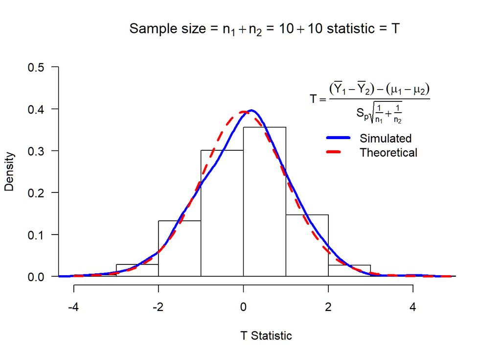

```r
tsim_plot1 = myTsim2(n1 = 10, n2 = 10, mean1 = 5, mean2 = 10, sigma1 = 4, sigma2 = 4, iter = 1000, x=1.5)
```

- Plot 2

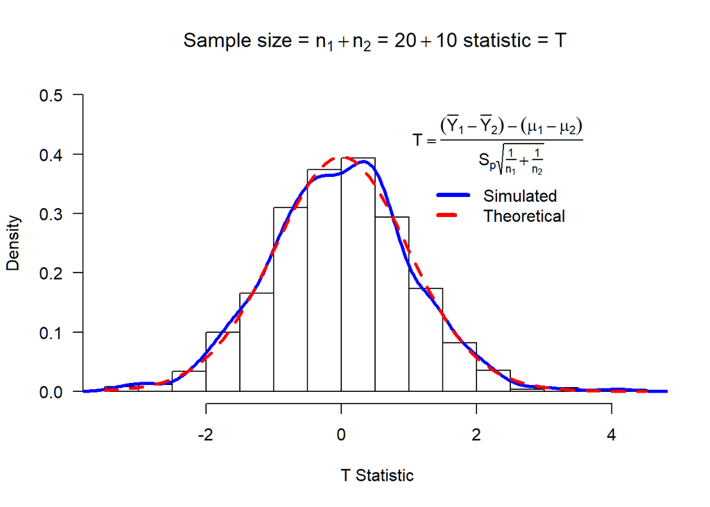

```r
tsim_plot2 = myTsim2(n1 = 20, n2 = 10, mean1 = 3, mean2 = 5, sigma1 = 10, sigma2 = 10, iter = 1000, x=1)
```

- Plot 3

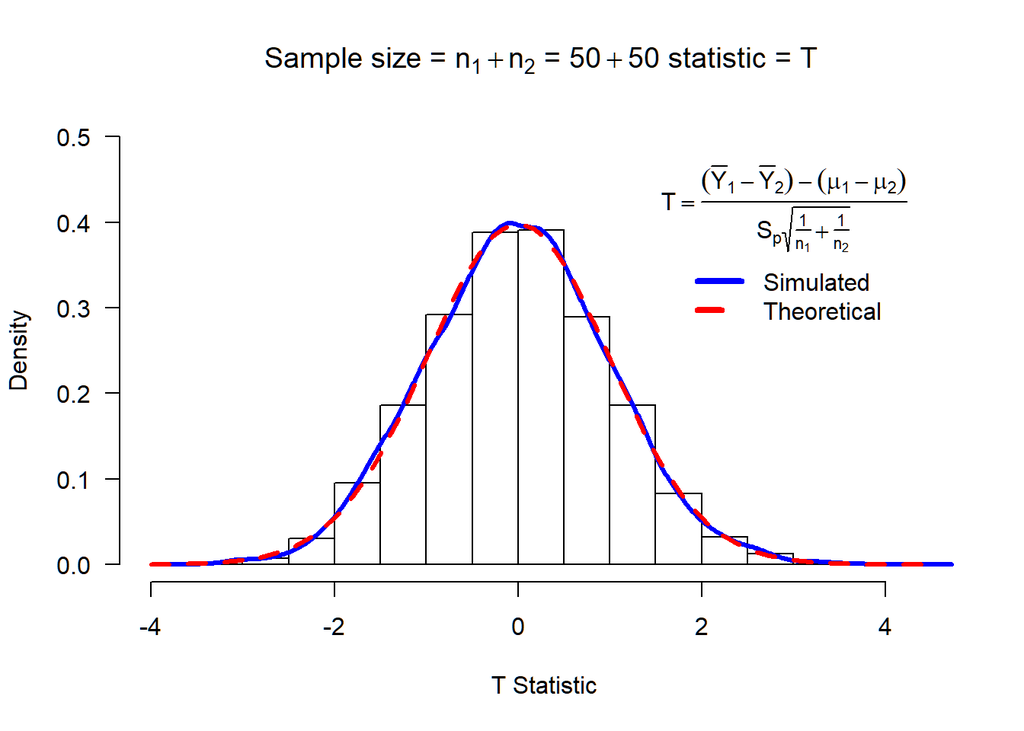

```r
tsim_plot3 = myTsim2(n1 = 50, n2 = 50, mean1 = 5, mean2 = 10, sigma1 = 4, sigma2 = 4, iter = 10000, x=1.5)
```

- Plot 4

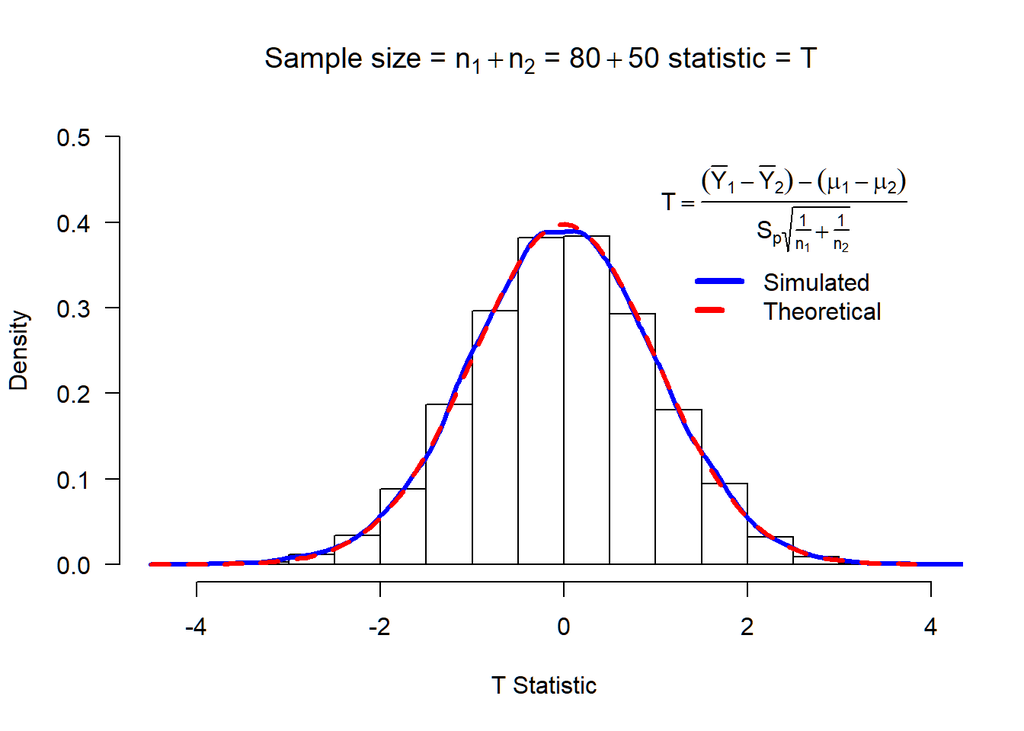

```r
tsim_plot4 = myTsim2(n1 = 80, n2 = 50, mean1 = 3, mean2 = 5, sigma1 = 10, sigma2 = 10, iter = 10000, x=1)
```

For the case with default parameters and `iter = 10000`, the plot and histogram of T statistics is as follows:

```r
tsim2 = myTsim2(iter = 10000)
```

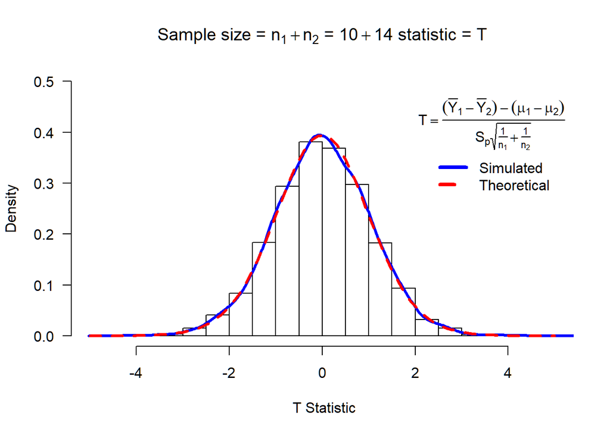

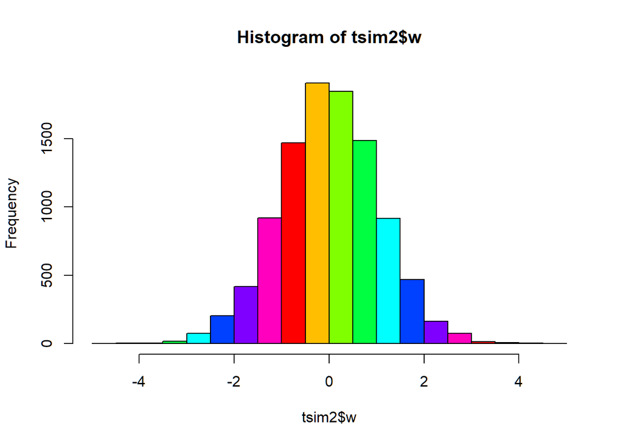

```r
hist(tsim2$w, col = rainbow(8))
```

# Task 6

In this task, the F statistic is explored. The F statistic will be created from two normal populations using the `myFsim2` function shown below.

```r
myFsim2<-function(n1=10,n2=14,sigma1=3,sigma2=2,mean1=5,mean2=10,iter=1000,ymax=0.9,x=6,y=0.5,...){
y1=rnorm(n1*iter,mean=mean1,sd=sigma1)# generate iter samples of size n1
y2=rnorm(n2*iter,mean=mean2,sd=sigma2)
data1.mat=matrix(y1,nrow=n1,ncol=iter,byrow=TRUE) # Each column is a sample size n1
data2.mat=matrix(y2,nrow=n2,ncol=iter,byrow=TRUE)
ssq1=apply(data1.mat,2,var) # ssq1 is s squared
ssq2=apply(data2.mat,2,var)
#spsq=((n1-1)*ssq1 + (n2-1)*ssq2)/(n1+n2-2) # pooled s squared
w=ssq1*sigma2^2/(ssq2*sigma1^2) #
hist(w,freq=FALSE, ylim=c(0,ymax), # Histogram with annotation
main=substitute(paste("Sample size = ",n[1]+n[2]," = ",n1+n2," statistic = ",F)),
xlab=paste("F Statistic",sep=""), las=1)
lines(density(w),col="Blue",lwd=3) # add a density plot
curve(df(x,n1-1,n2-1),xlim=c(0,6),add=TRUE,col="Red",lty=2,lwd=3) # add a theoretical curve
title=expression(F==frac(s[1]^2,s[2]^2)*frac(sigma[2]^2,sigma[1]^2)) #mathematical annotation -see ?plotmath
legend(x,y,c("Simulated","Theoretical"),col=c("Blue","Red"),lwd=4,lty=1:2,bty="n",title=title)# Legend #
return(list(w=w,summary=summary(w),sd=sd(w),fun="F")) # some output to use if needed
}
```

The F statistic is defined as follows:
$$F = \Bigg(\frac{S_1^2}{S_2^2} \Bigg)\Bigg(\frac{\sigma_2^2}{\sigma_1^2}\Bigg)$$

To show the F statistic in action, the four following plots are made:

- Plot 1

```r
f1 = myFsim2(n1 = 10, n2 = 10, mean1 = 5, mean2 = 10, sigma1 = 4, sigma2 = 4, iter = 1000)
```

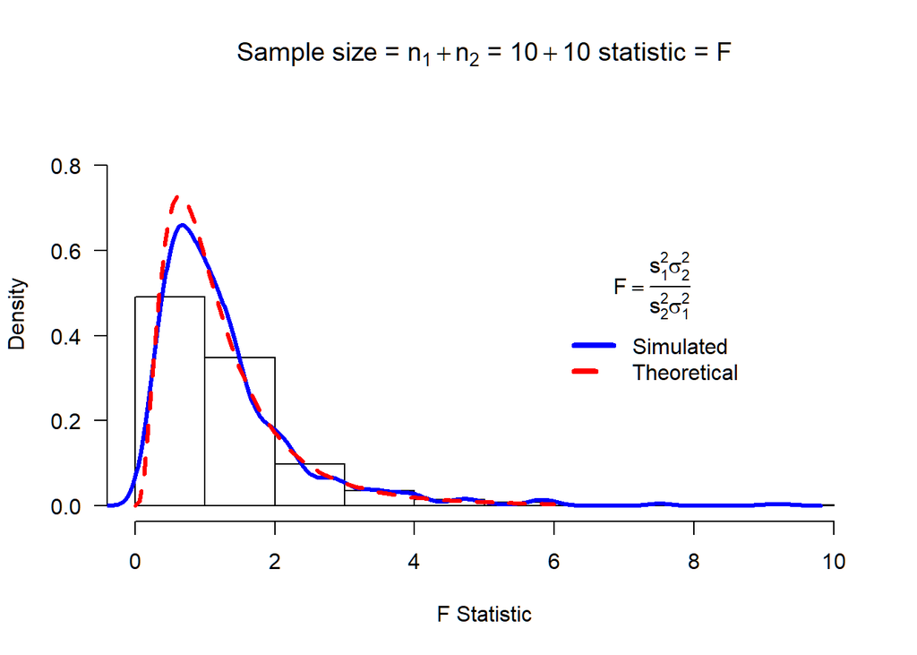

- Plot 2

```r
f2 = myFsim2(n1 = 30, n2 = 10, mean1 = 5, mean2 = 10, sigma1 = 4, sigma2 = 4, iter = 1000)
```

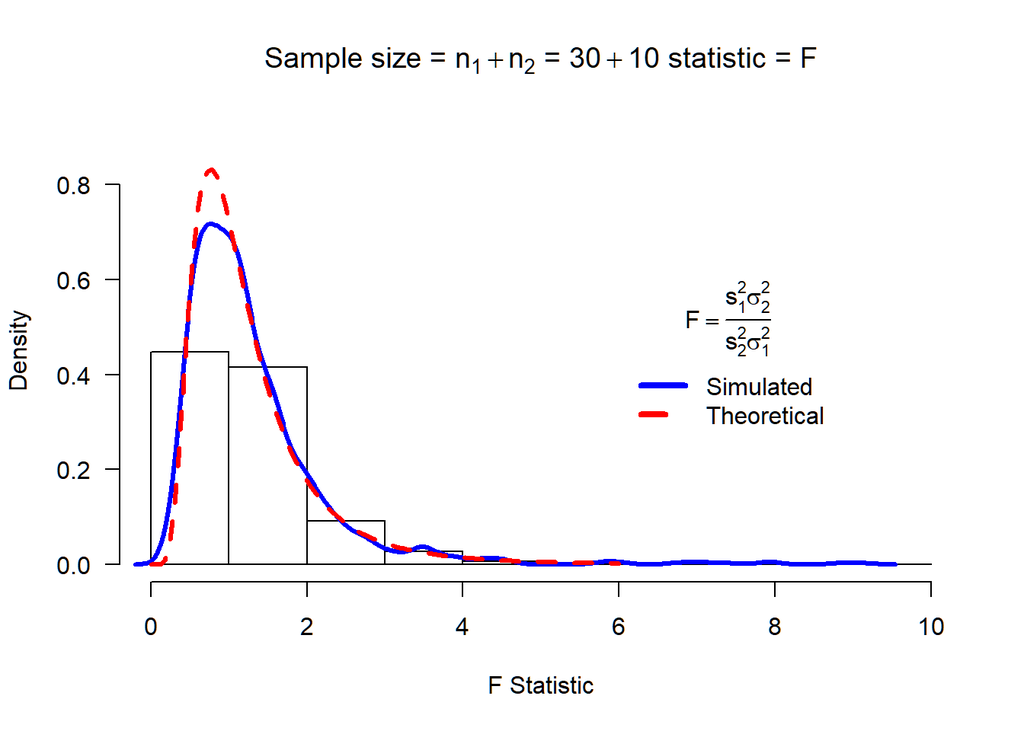

- Plot 3

```r
f3 = myFsim2(n1 = 50, n2 = 30, mean1 = 2, mean2 = 8, sigma1 = 10, sigma2 = 10, iter = 1000, ymax = 1.5, x = 1.75, y = 1)
```

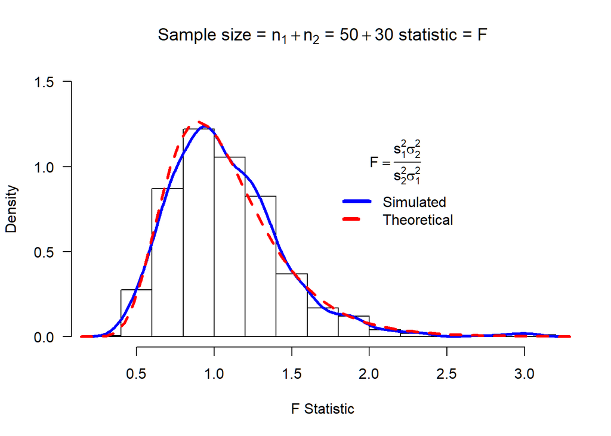

- Plot 4

```r
f1 = myFsim2(n1 = 80, n2 = 80, mean1 = 8, mean2 = 2, sigma1 = 10, sigma2 = 10, iter = 1000, ymax = 2, x = 1.75, y = 1)
```

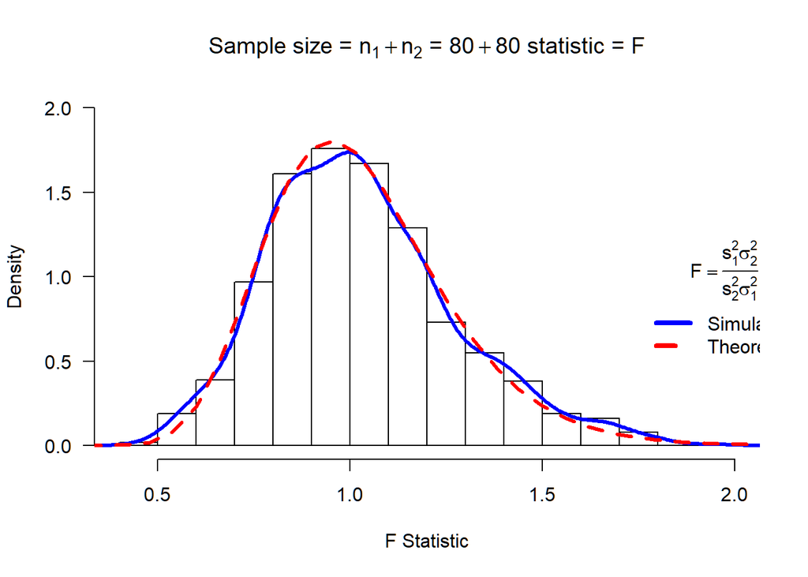

Finally, the histogram of the w variable can be found using the default values of the function.

```r
library(wesanderson)
fsim = myFsim2(x = 3)
```

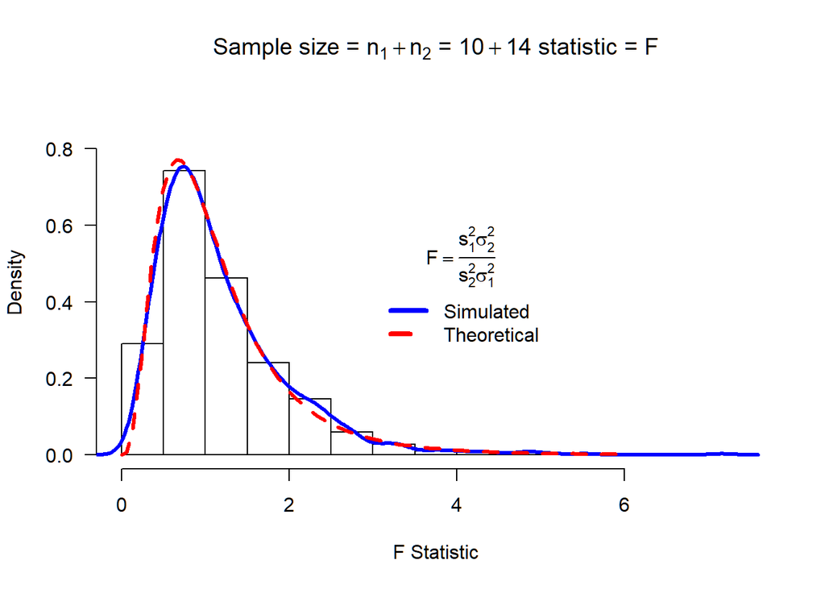

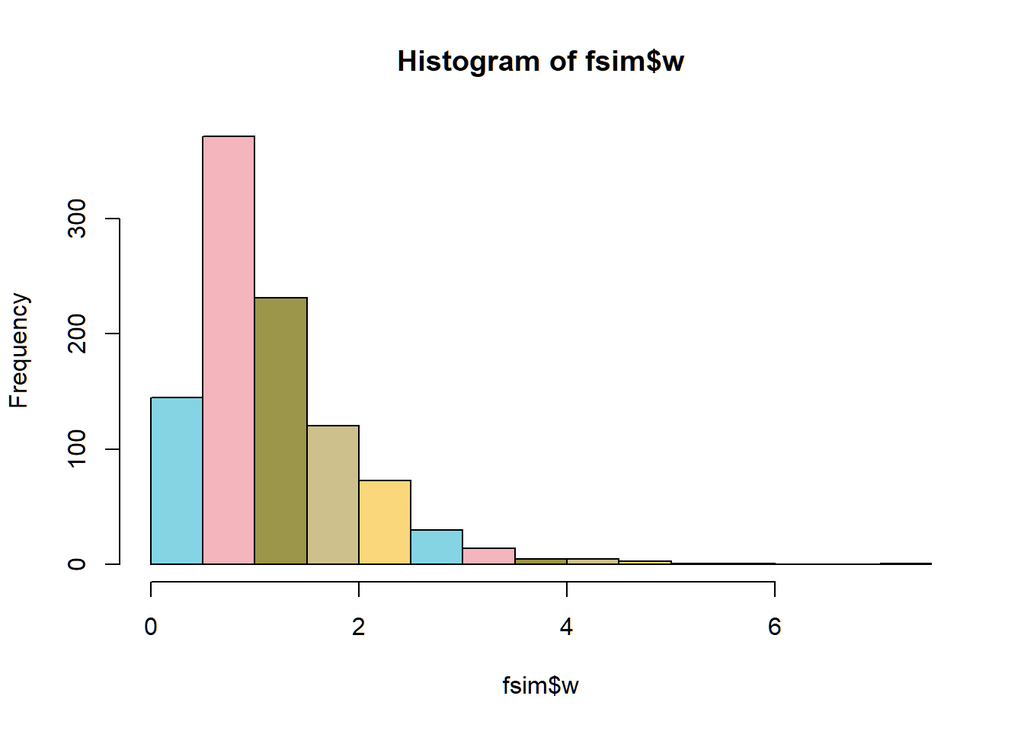

```r
hist(fsim$w, col = wes_palette("Moonrise3", 5, "discrete"))
```

# Task 7

```r
library(JKleiberPkg)
data("fire")
knitr::kable(head(fire))
```

| DISTANCE | DAMAGE |
| --- | --- |
| 3.4 | 26.2 |
| 1.8 | 17.8 |
| 4.6 | 31.3 |
| 2.3 | 23.1 |
| 3.1 | 27.5 |
| 5.5 | 36.0 |